# HW

author

2016年9月15日

# Part a

```r
data(ChickWeight)
#将weight数据提取出来，作为一个vector，这样方便操作一点。
weight <- ChickWeight$weight
```

## EDA

### 描述性

共收集到578条数据，weight的均值为 121.81，方差为5051.22，标准差为71.07.从直方图和密度图来看，weight似乎并不服从正态分布。

```r
# summary
length(weight);mean(weight);var(weight);sd(weight)
```

```
## [1] 578
```

```
## [1] 121.8183
```

```
## [1] 5051.223
```

```
## [1] 71.07196
```

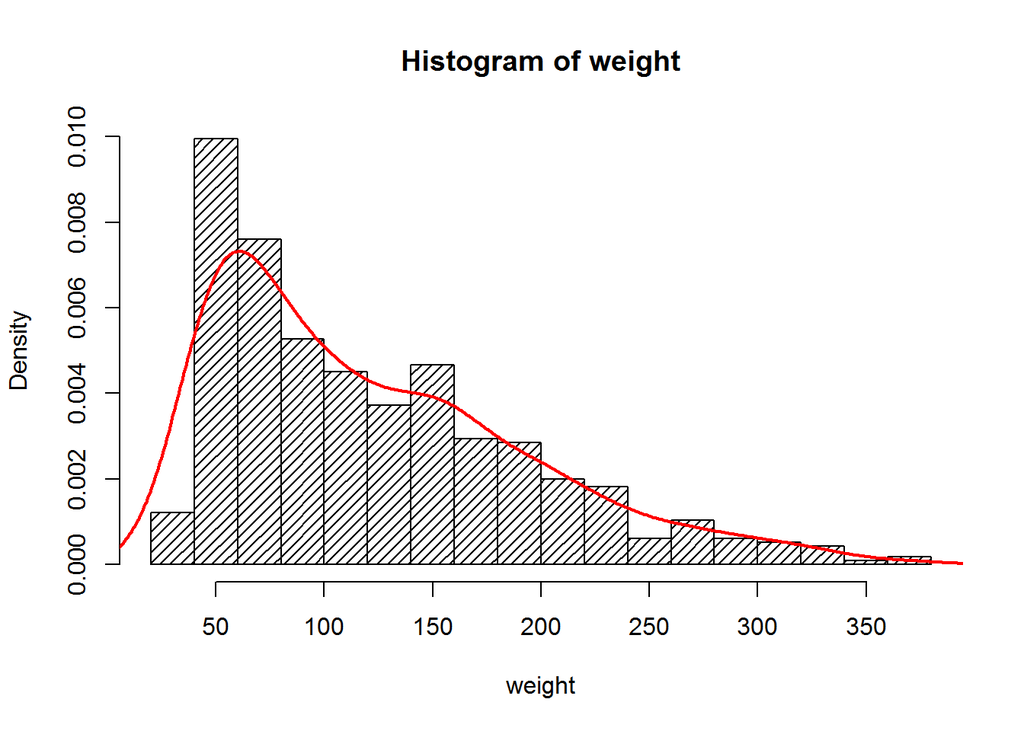

```r
hist(weight,freq = F,ylim = c(0,0.01),density = 20,breaks=20)
lines(density(weight),col='red',lwd=2)
```

## 四分位数和箱图

```r
# Quartile and Boxplot
quantile(weight)
```

```
##     0%    25%    50%    75%   100%
##  35.00  63.00 103.00 163.75 373.00
```

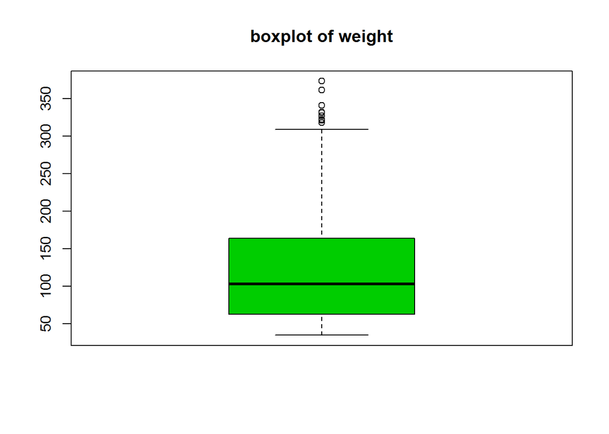

```r
boxplot(weight,col=3)
title(main = 'boxplot of weight')
```

### 正态性

- 从qq图来看，数据似乎并服从正态分布；
- shapiro.test 的P值非常显著，因此淡定数据不服从正态分布。

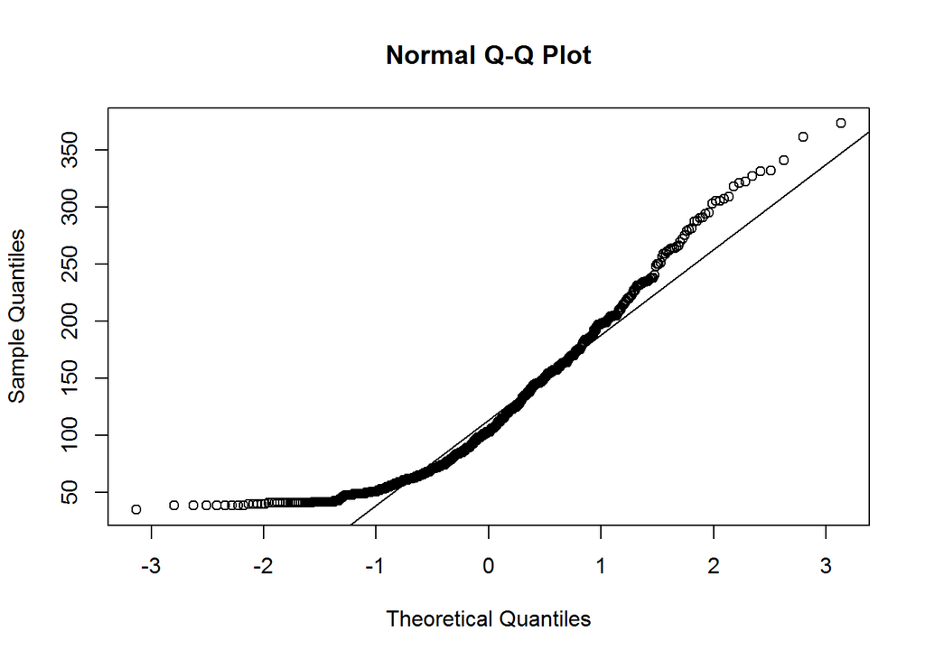

```r
# qqplot and Shapiro-Wilk normality test
qqnorm(weight)
qqline(weight)
```

```r
shapiro.test(weight)
```

```
##
##  Shapiro-Wilk normality test
##
## data:  weight
## W = 0.90866, p-value < 2.2e-16
```

# part b

## Jackknife

- 标准差偏差为-0.036
- 中位数偏差为 0

```r
## Jackknife
r <- length(weight) # 分组组数
j_sd <- numeric(r) # 建立空数组，为了保存抽样值
j_md <- numeric(r) # 建立空数组，为了保存抽样值

for (i in 1:r) {
    j_sd[i] <-sd(weight[-i])
    j_md[i] <-median(weight[-i])
}

# 计算 bias
(bias_jk_sd <- (r-1) * (mean(j_sd)-sd(weight))) # 计算 the standard deviation的 bias
```

```
## [1] -0.03646702
```

```r
(bias_jk_sd <- (r-1) * (mean(j_md)-median(weight))) # 计算 the median的bias
```

```
## [1] 0
```

## Bootstrap

- 标准差偏差为-0.093
- 中位数偏差为 0.631

```r
##Bootstrap

n <- length(weight) # 每组元素数量
B <- 2000 # 分组组数
b_sd <- numeric(r) # 建立空数组，为了保存抽样值
b_md <- numeric(r) # 建立空数组，为了保存抽样值

set.seed(1)  # 设定随机种子，可以使得结果重现。
# 模拟Bootstrap，重复2000次。
for (i in 1:B) {
    ind <- sample(x = 1:n,size = n,replace = T)
    b_sd[i] <- sd(weight[ind])
    b_md[i] <- median(weight[ind])
}

# 计算 bias
(bias_bs_sd <- mean(b_sd -sd(weight)))  # 计算 the standard deviation的 bias
```

```
## [1] -0.09329331
```

```r
(bias_bs_md <- mean(b_md -median(weight))) # 计算 the median的bias
```

```
## [1] 0.6305
```

# Part c

加载所需要的包。

```r
library(HH)
library(gplots)
```

按照按照不同分布（Diet），绘制成长时间（Time）内的weight的均值区间，并且拟合曲线。 得到以下几个结论：

- 四个组开始的时候，组内小鸡的平均重量似乎相等；
- 四个组的增长趋势似乎不同；
- 21天后，四个组的小鸡的重量似乎不相同。

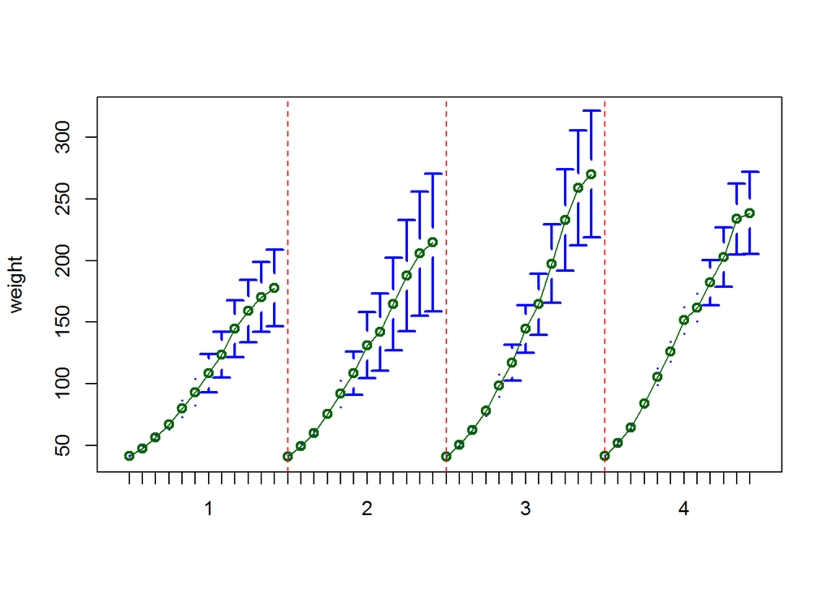

```r
#这里a 是个魔性代码。。。仅仅是为了绘制图的时候使用。。。没有任何计算的意义
a <- c(c(rep(' ',6),'1',rep(' ',5)),
   c(rep(' ',6),'2',rep(' ',5)),
   c(rep(' ',6),'3',rep(' ',5)),
   c(rep(' ',6),'4',rep(' ',5)))


# 绘制均值图
plotmeans( weight~ interaction(Time , Diet, sep ="   "),
           connect=list(1:12,13:24,25:36,37:48),
           barwidth=2,
           col="dark green",
           data=ChickWeight,n.label=F,legend=a,xlab=''
)
abline(v=c(13,25,37), lty=2,col='red')
```

多重分析结论如下：

```r
ancova(weight~Diet*Time,data=ChickWeight)
```

```
## Analysis of Variance Table
##
## Response: weight
##            Df  Sum Sq Mean Sq  F value    Pr(>F)
## Diet        3  155863   51954   44.766 < 2.2e-16 ***
## Time        1 2016357 2016357 1737.367 < 2.2e-16 ***
## Diet:Time   3   80804   26935   23.208 3.474e-14 ***
## Residuals 570  661532    1161
## ---
## Signif. codes:  0 '***' 0.001 '**' 0.01 '*' 0.05 '.' 0.1 ' ' 1
```

[figure not shown]

```r
aggregate(weight~Diet,data=ChickWeight[ChickWeight$Time==0,],FUN = mean)
```

```
##   Diet weight
## 1    1   41.4
## 2    2   40.7
## 3    3   40.8
## 4    4   41.0
```

```r
summary(aov(weight~Diet,data=ChickWeight[ChickWeight$Time==0,]))
```

```
##             Df Sum Sq Mean Sq F value Pr(>F)
## Diet         3   4.32   1.440   1.132  0.346
## Residuals   46  58.50   1.272
```

```r
aggregate(weight~Diet,data=ChickWeight[ChickWeight$Time==21,],FUN = mean)
```

```
##   Diet   weight
## 1    1 177.7500
## 2    2 214.7000
## 3    3 270.3000
## 4    4 238.5556
```

```r
summary(aov(weight~Diet,data=ChickWeight[ChickWeight$Time==21,]))
```

```
##             Df Sum Sq Mean Sq F value  Pr(>F)
## Diet         3  57164   19055   4.655 0.00686 **
## Residuals   41 167839    4094
## ---
## Signif. codes:  0 '***' 0.001 '**' 0.01 '*' 0.05 '.' 0.1 ' ' 1
```